# Czy warto się bić?

Agata Zywert

7 czerwca 2018

### Jakie są psychologiczne plusy bicia ludzi?

Ogólnie może kogoś to śmieszyć, ale nie jest to śmieszne. Badania wskazują, że sztuki walki pozytywnie wpływają na wiele aspektów zdrowia, a co ważne dla nas przyszłych i niedoszłych psychologów sztuki walki wpłtwają pozytywnie na psychologiczny well-being a także np. zmniejszają agresję u dzieci z ADHD (Woodward, 2009)

### Jak bicie ludzi może pomóc dzieciom.

Badania (i to eksperymentalne!) pokazały, że trenowanie sztuk walki pomaga w samoregulacji u dzieci `oni akurat użyli teakwondo, które imo jest trochę lamerskie`, no ale co poradzić (Lakes & Hoyt, 2004)

### Jakie pytania warto sobie zadać odnośnie relacji sztuki walki/zdrowie psychiczne

1. Czy sztuki walki mogą pomóc osobom o za niskiej samoocenie?
2. Czy osoby o lepszej samoocenie mają lepsze wyniki sportowe?
3. Czy ryzyko urazu i możliwość załamki po przegranych zawodach jest na tyle duży ryzykiem, że zważając na wszystkie plusy tej dziedziny warto się ich obawiać?
4. Czy sztuki walki mogą terapeutycznie pomóc np. ofiarom napadów lub gwałtów?

### Czemu to jest ciekawe?

- Nie wiem
- Ale bardzo mocno chiałabym zająć się tym w przyszłości
- Chciałabym też wiedzieć, czemu ludzie przerywają trening
- I czemu nie można kupić tytanowych więzadeł

### Cieszę się, że przyszłam na tipny

Od kiedy okazało się, że można robić takie ładne spisy treści to moje życie odmieniło się na lepsze. Wcześniej też nie umiałam cytowań, a teraz spokojnie mogę zostać naukowcem. W domu nauczyłam się jeszcze, że można dodać kliczek, która pozwala odbiorcy na ukrywanie i pokazywanie kodu.

### Oto są takie code chunki

```r
library(tidyverse)
diamonds %>%
  filter (cut == "Premium") %>%
  arrange(desc(price)) %>%
  top_n(10)
```

| carat | cut | color | clarity | depth | table | price | x | y | z |
| --- | --- | --- | --- | --- | --- | --- | --- | --- | --- |
| 3.01 | Premium | J | SI2 | 60.7 | 59 | 18710 | 9.35 | 9.22 | 5.64 |
| 3.51 | Premium | J | VS2 | 62.5 | 59 | 18701 | 9.66 | 9.63 | 6.03 |
| 3.67 | Premium | I | I1 | 62.4 | 56 | 16193 | 9.86 | 9.81 | 6.13 |
| 4.01 | Premium | I | I1 | 61.0 | 61 | 15223 | 10.14 | 10.10 | 6.17 |
| 4.01 | Premium | J | I1 | 62.5 | 62 | 15223 | 10.02 | 9.94 | 6.24 |
| 3.24 | Premium | H | I1 | 62.1 | 58 | 12300 | 9.44 | 9.40 | 5.85 |
| 2.00 | Premium | H | SI2 | 58.9 | 57 | 12210 | 8.09 | 58.90 | 8.06 |
| 3.05 | Premium | E | I1 | 60.9 | 58 | 10453 | 9.26 | 9.25 | 5.66 |
| 3.01 | Premium | F | I1 | 62.2 | 56 | 9925 | 9.24 | 9.13 | 5.73 |
| 3.01 | Premium | I | I1 | 62.7 | 58 | 8040 | 9.10 | 8.97 | 5.67 |

### Cytowanie innego kodu niż R

Fragment pierwszej giery, która napisałam w pygame, co to za cudowne czasy były

```
def drawBox(self,x, y, color = 'yellow'):
            c_draw.create_rectangle([x, y, x + self.size, y + self.size], fill=color)
        def draw(self):
            c_draw.delete("all")
            if self.col:
                c_draw.create_text([self.width / 2 * self.size, self.height / 2 * self.size], text = "Przegrałeś› słabiaku.\nZakonczłeś› na wężu o długości {w}.".format(w = len(self.msnake)), font=("Arial", 20), justify = tk.CENTER)
```

### Uruchamianie innego kodu niż R

```python
def grade_converter(grade):
    if grade >= 90 :
        return "A"
    elif grade >=80:
        return "B"
    elif grade >=70 :
        return "C"
    elif grade >=65:
        return "D"
    else:
        return "F"

print grade_converter(92)
```

```
## A
```

### Jeszcze jakiś ggplocik

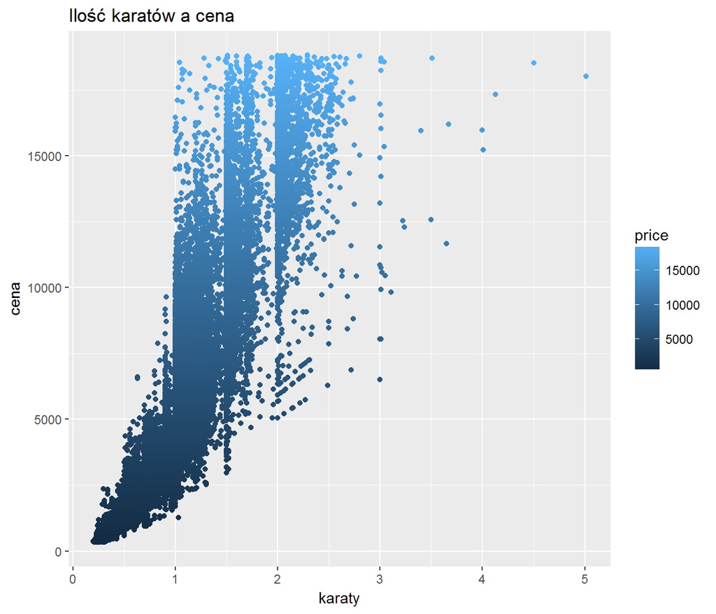

### Wstawiam fotkę, ponieważ tak

[figure not shown]

### Bibliografia

Lakes, K. D., & Hoyt, W. T. (2004). Promoting self-regulation through school-based martial arts training. *Journal of Applied Developmental Psychology*, *25*(3), 283–302. https://doi.org/10.1016/j.appdev.2004.04.002

Twemlow, S. W., & Sacco, F. C. (1998). The application of traditional martial arts practice and theory to the treatment of violent adolescents.

Woodward, T. W. (2009). A review of the effects of martial arts practice on health. *Wisconsin Medical Journal*, *108*(1), 40–43. Retrieved from http://www.ncbi.nlm.nih.gov/pubmed/19326635